# Parametrized Curves

A parametrized curve allows you to fully characterize a curve with a single parameter instead of a pair or a triple of coordinates. It allows for the beautiful plots you are about to see, so I'd argue it's quite important.

## Definition

Let $\gamma: I\to \mathbb{R}^3$, where $I$ is an interval in $\mathbb{R}$. We say that $\gamma$ is a **parametrized curve**. let $t\in I$. Then $\gamma(t)=((x(t),y(t),z(t))$ is a point on the curve.

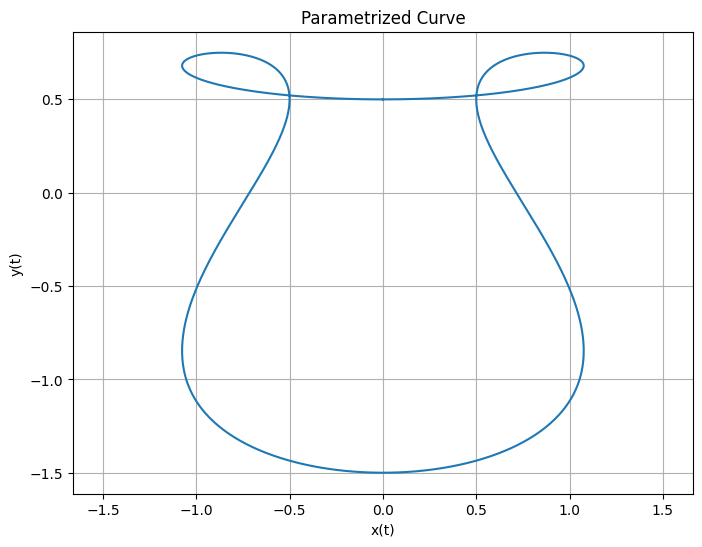

```python
import numpy as np
import matplotlib.pyplot as plt

# Define the parameter t
t = np.linspace(0, 2 * np.pi, 1000)

# Define the parametric equations for x(t) and y(t)
x = np.sin(t) + np.sin(3*t)/2
y = np.cos(t) - np.cos(2*t)/2

# Plot the curve
plt.figure(figsize=(8, 6))
plt.plot(x, y)
plt.title("Parametrized Curve")
plt.xlabel("x(t)")
plt.ylabel("y(t)")
plt.grid(True)
plt.axis('equal')
plt.show()
```

The example above is a curve in the plane and it is not really in a regular shape. Let's consider some familiar examples below:

### A Circle in $\mathbb{R}^2$

Given by the parametrization $$ \gamma(t)=(R\cos t, R\sin t), t\in I=[0,2\pi] $$

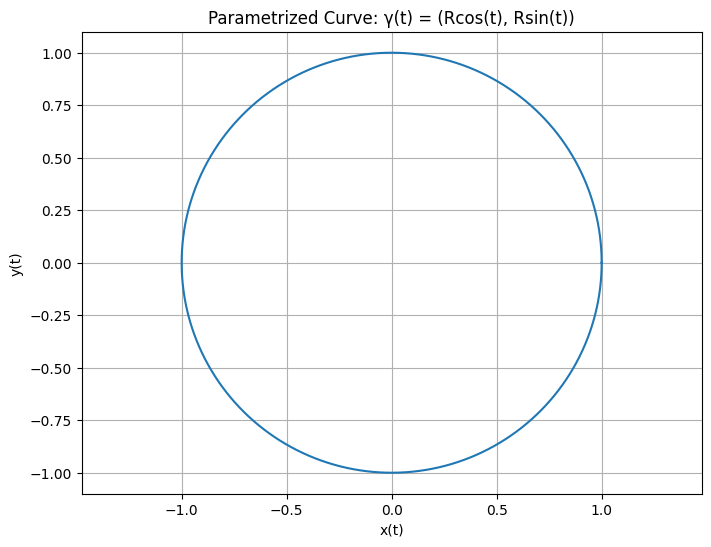

```python
# Define the parameter t
t = np.linspace(0, 2 * np.pi, 1000)

# Given R (you can adjust its value)
R = 1

# Define the parametric equations for x(t) and y(t)
x = R * np.cos(t)
y = R * np.sin(t)

# Plot the curve
plt.figure(figsize=(8, 6))
plt.plot(x, y)
plt.title("Parametrized Curve: γ(t) = (Rcos(t), Rsin(t))")
plt.xlabel("x(t)")
plt.ylabel("y(t)")
plt.grid(True)
plt.axis('equal')
plt.show()
```

### A circle in $\mathbb{R}^3$

Given by $$ \gamma(t)=(R\cos t, R\sin t, c), t\in I=[0,2\pi] $$for a constant number $c$.

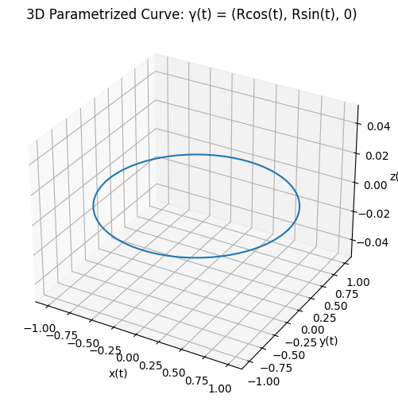

```python
from mpl_toolkits.mplot3d import Axes3D

# Define the parameter t
t = np.linspace(0, 2 * np.pi, 1000)

# Given R (you can adjust its value)
R = 1

# Define the parametric equations for x(t), y(t), and z(t)
x = R * np.cos(t)
y = R * np.sin(t)
z = 0

# Create a 3D plot
fig = plt.figure(figsize=(8, 6))
ax = fig.add_subplot(111, projection='3d')

# Plot the curve
ax.plot(x, y, z)
ax.set_title("3D Parametrized Curve: γ(t) = (Rcos(t), Rsin(t), 0)")
ax.set_xlabel("x(t)")
ax.set_ylabel("y(t)")
ax.set_zlabel("z(t)")
ax.grid(True)
plt.show()
```